# Sandbox

#Libraries

```r
library(tidyverse)
library(dplyr)
library(MASS)
library(rstanarm)
library(ggplot2)
library(data.table)
library(stringr)
library(ggsoccer)
library(caret)
library(jsonlite)
library(stringi)
```

# Data Loading

We first want to load in the events data, which split across multiple csv files, grouped by country. To read this in, I have defined a loop that iterates through the data directory and appends each file to a data-frame.

```r
#Define Data Directory
dir_path <- "../Data/events"

#Get a list of files in the directory
file_list <- list.files(dir_path)

#Create an empty data frame to store the file contents
actions <- data.frame()

#Loop through the files and add their contents to the data frame
for (i in 1:length(file_list)) {
  #Read the file into a data frame
  file_data <- fread(file.path(dir_path, file_list[i]))

  #Add the file data to the main data frame
  actions <- rbind(actions, file_data)
}
```

```r
#View the events data frame
actions
```

| eventId | subEventName | tags | playerId | positions | matchId | eventName | teamId | matchPeriod | eventSec | subEventId | id | tagsList | pos_orig_y | pos_orig_x | pos_dest_y | pos_dest_x |
| --- | --- | --- | --- | --- | --- | --- | --- | --- | --- | --- | --- | --- | --- | --- | --- | --- |
| 8 | Simple pass | [{'id': 1801}] | 25413 | [{'y': 49, 'x': 49}, {'y': 78, 'x': 31}] | 2499719 | Pass | 1609 | 1H | 2.758649 | 85 | 177959171 | [1801] | 49 | 49 | 78 | 31 |
| 8 | High pass | [{'id': 1801}] | 370224 | [{'y': 78, 'x': 31}, {'y': 75, 'x': 51}] | 2499719 | Pass | 1609 | 1H | 4.946850 | 83 | 177959172 | [1801] | 78 | 31 | 75 | 51 |
| 8 | Head pass | [{'id': 1801}] | 3319 | [{'y': 75, 'x': 51}, {'y': 71, 'x': 35}] | 2499719 | Pass | 1609 | 1H | 6.542188 | 82 | 177959173 | [1801] | 75 | 51 | 71 | 35 |
| 8 | Head pass | [{'id': 1801}] | 120339 | [{'y': 71, 'x': 35}, {'y': 95, 'x': 41}] | 2499719 | Pass | 1609 | 1H | 8.143395 | 82 | 177959174 | [1801] | 71 | 35 | 95 | 41 |
| 8 | Simple pass | [{'id': 1801}] | 167145 | [{'y': 95, 'x': 41}, {'y': 88, 'x': 72}] | 2499719 | Pass | 1609 | 1H | 10.302366 | 85 | 177959175 | [1801] | 95 | 41 | 88 | 72 |
| 8 | Simple pass | [{'id': 1802}] | 3319 | [{'y': 88, 'x': 72}, {'y': 75, 'x': 77}] | 2499719 | Pass | 1609 | 1H | 12.548934 | 85 | 177959177 | [1802] | 88 | 72 | 75 | 77 |
| 8 | Head pass | [{'id': 1801}] | 8653 | [{'y': 25, 'x': 23}, {'y': 15, 'x': 39}] | 2499719 | Pass | 1631 | 1H | 13.961228 | 82 | 177959186 | [1801] | 25 | 23 | 15 | 39 |
| 1 | Air duel | [{'id': 701}, {'id': 1802}] | 8013 | [{'y': 15, 'x': 39}, {'y': 20, 'x': 33}] | 2499719 | Duel | 1631 | 1H | 14.765321 | 10 | 177959189 | [701, 1802] | 15 | 39 | 20 | 33 |
| 1 | Air duel | [{'id': 703}, {'id': 1801}] | 0 | [{'y': 85, 'x': 61}, {'y': 80, 'x': 67}] | 2499719 | Duel | 1609 | 1H | 14.765321 | 10 | 177961218 | [703, 1801] | 85 | 61 | 80 | 67 |
| 8 | Head pass | [{'id': 1401}, {'id': 1801}] | 167145 | [{'y': 80, 'x': 67}, {'y': 61, 'x': 59}] | 2499719 | Pass | 1609 | 1H | 15.320341 | 82 | 177959178 | [1401, 1801] | 80 | 67 | 61 | 59 |

[output cut: 990 more lines]

We next want to load in the player data

```r
#Read in data
players <- fromJSON("../Data/players/players.json")
```

```r
#View player data
players
```

|  | passportArea | weight | firstName | middleName | lastName | currentTeamId | birthDate | height | role | birthArea | wyId | foot | shortName | currentNationalTeamId |
| --- | --- | --- | --- | --- | --- | --- | --- | --- | --- | --- | --- | --- | --- | --- |
| 1 |  | 78 | Harun |  | Tekin | 4502 | 1989-06-17 | 187 |  |  | 32777 | right | H. Tekin | 4687 |
| 2 |  | 73 | Malang |  | Sarr | 3775 | 1999-01-23 | 182 |  |  | 393228 | left | M. Sarr | 4423 |
| 3 |  | 72 | Over |  | Mandanda | 3772 | 1998-10-26 | 176 |  |  | 393230 |  | O. Mandanda | null |
| 4 |  | 82 | Alfred John Momar |  | N'Diaye | 683 | 1990-03-06 | 187 |  |  | 32793 | right | A. N'Diaye | 19314 |
| 5 |  | 84 | Ibrahima |  | Konat\\u00e9 | 2975 | 1999-05-25 | 192 |  |  | 393247 | right | I. Konat\\u00e9 | null |
| 6 |  | 83 | Jasper |  | Cillessen | 676 | 1989-04-22 | 185 |  |  | 33 | right | J. Cillessen | 664 |
| 7 |  | 91 | Toby |  | Alderweireld | 1624 | 1989-03-02 | 187 |  |  | 36 | right | T. Alderweireld | 5629 |
| 8 |  | 88 | Jan |  | Vertonghen | 1624 | 1987-04-24 | 189 |  |  | 48 | left | J. Vertonghen | 5629 |
| 9 |  | 74 | Alexander |  | Djiku | 3783 | 1994-08-09 | 182 |  |  | 229427 | right | A. Djiku | null |
| 10 |  | 76 | Christian |  | Dannemann Eriksen | 1624 | 1992-02-14 | 180 |  |  | 54 | right | C. Eriksen | 7712 |

[output cut: 990 more lines]

Since the event data contains all sorts of event types, we now want to filter out only the shots.

```r
# Extract observations of shots from the actions data
shots_df <- actions %>% dplyr::filter(subEventName == "Shot")
```

## Event Data

The next section is dedicated to loading the event data

### Categorical Data

We now use documentation from [here](https://dataglossary.wyscout.com/shot/) to mutate the data, and garner more useful categorical data about the shot itself.

```r
shots_df <- shots_df %>%

  #If the shot is successful
  mutate('is_goal' = ifelse(grepl(" 101}", shots_df$tags),1,0),

         #If the shot is at the end of a counter-attack
         'is_CA' = ifelse(grepl(" 1901}", shots_df$tags),1,0),

         #If the shot is with the foot or another part of the body
         'body_part' = ifelse(grepl(" 401}", shots_df$tags),"left",
                              ifelse(grepl(" 402}", shots_df$tags), "right",
                                   ifelse(grepl(" 403}", shots_df$tags), "head/body", "NA"))),

         #If the shot is blocked
         'is_blocked' = ifelse(grepl(" 2101}", shots_df$tags), 1,0))

#Filter out only unblocked shots
shots_df <- shots_df %>% dplyr::filter(is_blocked == 0)

#Keep necessary categorical data
shots_cat <- dplyr::select(shots_df, c('playerId', 'is_goal', 'is_CA', 'body_part'))

summary(shots_cat)
```

```
    playerId         is_goal           is_CA          body_part
 Min.   :     0   Min.   :0.0000   Min.   :0.00000   Length:32851
 1st Qu.: 11066   1st Qu.:0.0000   1st Qu.:0.00000   Class :character
 Median : 25707   Median :0.0000   Median :0.00000   Mode  :character
 Mean   : 93637   Mean   :0.1366   Mean   :0.05793
 3rd Qu.:142755   3rd Qu.:0.0000   3rd Qu.:0.00000
 Max.   :552555   Max.   :1.0000   Max.   :1.00000
```

### Positional Data

We now calculate the distance from the goal and angle to goal for each shot.

First, we would like to define the position of each shot on the pitch

```r
#Extract all numeric entries from the positions column
pos <- str_extract_all(gsub('"', "", shots_df$positions), "\\d+")

#Define vectors to store coordinates
x_pos <- c()
y_pos <- c()

#Loops that extract the coordinates
for (i in 1:length(pos)){
  x_pos <- append(x_pos, pos[[i]][2])
}

for (i in 1:length(pos)){
  y_pos <- append(y_pos, pos[[i]][1])
}

#Convert coordinates to numeric data
x_pos <- x_pos %>% as.numeric()
y_pos <- y_pos %>% as.numeric()
```

```r
# Create coordinate dataframe
coords <- data.frame(x_pos, y_pos)
```

We can now use these coordinates to calculate distance and angle to goal

```r
#Define length and width of pitch

pitch_x <- 105
pitch_y <- 68

#We now convert coordinates to meters
x_meter <- coords$x_pos * pitch_x/100
y_meter <- coords$y_pos * pitch_y/100

# Calculate distances
dist <- sqrt((105 - x_meter)^2 + ((32.5) - y_meter)^2)

#Calculate angles
angles <- atan( (7.32 * (105 - x_meter) ) / ( (105 - x_meter)^2 + (32.5 - y_meter)^2 - (7.32/2)^2 )) * 180/pi
```

We can now merge our useful event data into one data-frame.

```r
#Concatenate data-frames
shots <- data.frame(shots_cat, dist, angles)
```

## Player Data

The next section is dedicated to loading the player data. For this, we simply filter only by the features that will prove useful later on.

First lets retrieve a vector of all unique players in the current `shots` data-base:

```r
player_list <- unique(shots$playerId)
```

We can now filter the `players` data-frame to only include these players

```r
shooters <- dplyr::filter(players, wyId %in% player_list)
```

We can filter this data-frame by the features we need.

```r
shooters <- dplyr::select(shooters, c('shortName', 'wyId', 'foot'))
```

Finally, we rename the some columns, for ease later on.

```r
colnames(shooters)[colnames(shooters) == "wyId"] <- "playerId"
colnames(shooters)[colnames(shooters) == "foot"] <- "preferred_foot"
```

### Preferred Foot Data

We will now introduce a preferred foot binary variable.

First we merge all our useful data into one data-frame

```r
#Concatenate data-frames
shots <- merge(shots, shooters, by = "playerId")
```

We now mutate this to add a column featuring the desired binary variable

```r
shots <- shots %>%
  mutate(preferred_foot_b = ifelse(shots$preferred_foot == shots$body_part, 1, 0))
```

Finally, we remove the `preferred_foot` column

```r
shots <- shots %>% dplyr::select(-c("preferred_foot"))
```

## Data Cleaning/Wrangling

Since much of our data is categorical, it is necessary to convert it to the factor type.

```r
#Convert necessary variables to factor

shots$is_goal <- shots$is_goal %>% as.factor()

shots$body_part <- shots$body_part %>% as.factor()

shots$is_CA <- shots$is_CA %>% as.factor()

shots$preferred_foot_b <- shots$preferred_foot_b %>% as.factor()
```

Now lets view a summary of our data

```r
summary(shots)
```

```
    playerId      is_goal   is_CA         body_part          dist            angles
 Min.   :    36   0:28360   0:30946   head/body: 6645   Min.   :  0.54   Min.   :-87.00
 1st Qu.: 11066   1: 4489   1: 1903   left     :10225   1st Qu.: 11.56   1st Qu.: 14.40
 Median : 25707                       right    :15979   Median : 15.99   Median : 19.64
 Mean   : 93642                                         Mean   : 17.88   Mean   : 23.54
 3rd Qu.:142755                                         3rd Qu.: 24.22   3rd Qu.: 30.59
 Max.   :552555                                         Max.   :103.97   Max.   : 89.66
  shortName         preferred_foot_b
 Length:32849       0:12623
 Class :character   1:20226
 Mode  :character
```

### Player Names

If we view a random subset of our data, we observe a problem decoding unicode characters:

```r
shots[90:100,]
```

|  | playerId | is_goal | is_CA | body_part | dist | angles | shortName | preferred_foot_b |
| --- | --- | --- | --- | --- | --- | --- | --- | --- |
| 90 | 54 | 0 | 0 | right | 10.084463 | 34.85131 | C. Eriksen | 1 |
| 91 | 54 | 0 | 0 | right | 29.022869 | 13.05092 | C. Eriksen | 1 |
| 92 | 54 | 0 | 0 | left | 13.684959 | 25.93017 | C. Eriksen | 0 |
| 93 | 54 | 0 | 0 | right | 27.333622 | 14.67510 | C. Eriksen | 1 |
| 94 | 54 | 0 | 0 | right | 18.688662 | 18.94516 | C. Eriksen | 1 |
| 95 | 56 | 0 | 0 | right | 27.743520 | 14.25515 | D. Klaassen | 1 |
| 96 | 66 | 1 | 0 | right | 19.115167 | 21.45685 | K. Sig\\u00fe\\u00f3rsson | 1 |
| 97 | 66 | 0 | 0 | right | 24.650414 | 15.19574 | K. Sig\\u00fe\\u00f3rsson | 1 |
| 98 | 66 | 0 | 0 | head/body | 11.890601 | 30.98532 | K. Sig\\u00fe\\u00f3rsson | 0 |
| 99 | 66 | 1 | 0 | right | 8.702074 | 31.65599 | K. Sig\\u00fe\\u00f3rsson | 1 |

[output cut: 1 more lines]

So we use the following chunk to decode them

```r
shots$shortName <- stringi::stri_unescape_unicode(shots$shortName)
```

### Negative Angles

We can see from the summary there are negative angles in the data, to investigate this further we can look at a histogram

[figure not shown]

```r
hist(shots$angles)
```

We observe that there are multiple negative angles. Since most of the angles are correctly positive, we will remove the negative ones from the analysis.

```r
shots <- shots %>% dplyr::filter(shots$angles > 0)
```

To see the corrected histogram

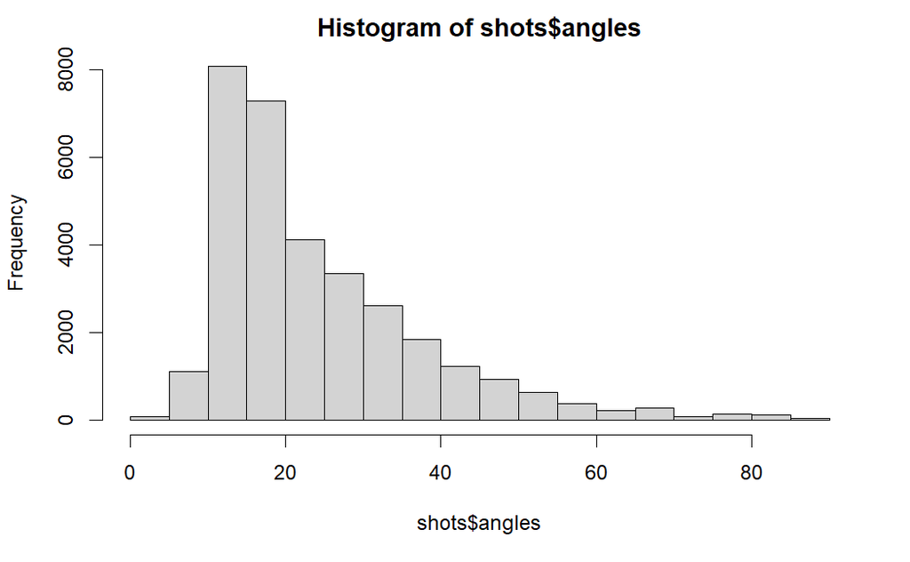

```r
hist(shots$angles)
```

### Player Downsampling

Later on we will use `playerId` to group the data. Since our data-set is large and spans many countries, there are many different players in the data-set

```r
length(table(shots$playerId))
```

```
[1] 2292
```

With this in hand, it would be sensible to limit the amount of “groups” (players) to, say 50. In order to preserve the greatest amount of data, we will use the top 50 most occurring player names.

```r
top_players <- sort(table(shots$playerId), decreasing = T)[1:50]
```

Now we filter the data based on these players

```r
top_shots <- dplyr::filter(shots, playerId %in% row.names(top_players))
```

We now view a summary of our final data

```r
summary(top_shots)
```

```
    playerId      is_goal  is_CA        body_part         dist            angles
 Min.   :   122   0:3299   0:3716   head/body: 756   Min.   : 3.679   Min.   : 2.041
 1st Qu.:  7905   1: 727   1: 310   left     :1329   1st Qu.:10.974   1st Qu.:15.430
 Median : 14945                     right    :1941   Median :14.749   Median :22.007
 Mean   : 53939                                      Mean   :16.472   Mean   :25.839
 3rd Qu.: 25716                                      3rd Qu.:20.832   3rd Qu.:32.098
 Max.   :447804                                      Max.   :98.898   Max.   :89.660
  shortName         preferred_foot_b
 Length:4026        0:1539
 Class :character   1:2487
 Mode  :character
```

# Data Exploration

To better understand our distance and angle data, we can create the following boxplots

```r
boxplot(dist ~ is_goal, data=shots_sub,xlab='Failure or Success', ylab = 'Distance to goal')
```

```r
boxplot(angles ~ is_goal, data=shots_sub,xlab='Failure or Success', ylab = 'Angle to goal')
```

It is likely that distance and angles have some sort of relationship.

```r
plot(shots_sub$angles, shots_sub$dist)
```

We now visualise the distribution of distances

```r
hist(shots_sub$dist)
```

```r
p<-ggplot(data=shots_sub, aes(x=body_part, fill=is_goal)) +
    geom_bar(stat="count")

p
```

# Fitting Models

## Data Splitting

```r
# Split into test and train subsets
train.size <- nrow(shots_sub) / 2
train <- sample(1:nrow(shots_sub), train.size)
test <- -train
shots.train <- shots_sub[train, ]
shots.test <- shots_sub[test, ]
is_goal.test <-  shots_sub$is_goal[test]
```

## Simple Logistic Regression Models

```r
#Fit Logistic Regression
glm_1 <- glm(is_goal ~ dist, family = "binomial", data = shots.train)

#Calculate mis-classification
glm_1_probs <-  predict(glm_1, shots.test, type = "response")
glm_1_pred <-  rep(0, length(glm_1_probs))
glm_1_pred[glm_1_probs > 0.5] <- 1

mean(glm_1_pred != is_goal.test)
```

```r
#Fit Logistic Regression
glm_2 <- glm(is_goal ~ dist + angles, family = "binomial", data = shots.train)

summary(glm_2)
```

```r
#Fit Logistic Regression
glm_3 <- glm(is_goal ~ dist + angles + body_part, family = "binomial", data = shots.train)

#Calculate mis-classification
glm_3_probs <-  predict(glm_3, shots.test, type = "response")
glm_3_pred <-  rep(0, length(glm_3_probs))
glm_3_pred[glm_3_probs > 0.5] <- 1

mean(glm_3_pred != is_goal.test)
```

## Bayesian Logistic Regression

### Bayesian Model 1 (distance)

```r
#Fit the model
bmod1 = stan_glm(result_id ~ distance,data=shots.train, family = binomial)
```

```r
#Model Summary
bmod1
```

```r
#Summary data on the priors
prior_summary(bmod1)
```

```r
#Retrieve and print posterior interval for the model
ci95_1 <- posterior_interval(bmod1, prob = 0.95)
round(ci95_1, 2)
```

```r
#Launch shinystan
launch_shinystan(bmod1, ppd = FALSE)
```

```r
#Calculate misclassification
bmod1.pred <-  posterior_predict(bmod1, shots.test, type = "response")

mean(bmod1.pred != is_goal.test)
```

### Bayesian Model 2 (distance + angles)

```r
bmod2 <- stan_glm(result_id ~ distance + angles ,data=shots.train, family = binomial)
```

```r
bmod2.pred <-  posterior_predict(bmod2, shots.test, type = "response")

mean(bmod2.pred != is_goal.test)
```

### Bayesian Model 3 (distance * angles)

```r
bmod3 <- stan_glm(result_id ~ distance * angles ,data=shots.train, family = binomial)
```

```r
bmod3.pred <- posterior_predict(bmod3, shots.test, type = "response")

mean(bmod3.pred != is_goal.test)
```

### Bayesian Model 4 (distance + bodypart heirarchical variable)

```r
bhmod <- stan_glmer(result_id ~ distance + (1 | bodypart_id),
                    data=shots.train, family = binomial)
```